# IS 4487 Assignment 5: Exploratory Data Analysis (EDA) with Stakeholder Framing

In this assignment, you will:

- Load and explore a hotel bookings dataset
- Identify stakeholder needs and frame your analysis around business goals
- Practice data summarization and visualization
- Draw insights that could lead to actionable business recommendations

## Why This Matters

These skills are essential for business majors and minors working in areas like marketing, operations, finance, or consulting. Understanding how to explore and communicate data-driven insights helps you make better decisions and contribute to real-world business outcomes.

## Dataset Description: Hotel Bookings

This dataset contains booking information for two types of hotels: a **city hotel** and a **resort hotel**. Each record corresponds to a single booking and includes various details about the reservation, customer demographics, booking source, and whether the booking was canceled.

**Source**: [GitHub - TidyTuesday: Hotel Bookings](https://github.com/rfordatascience/tidytuesday/blob/master/data/2020/2020-02-11/readme.md)

### Key Use Cases

- Understand customer booking behavior
- Explore factors related to cancellations
- Segment guests based on booking characteristics
- Compare city vs. resort hotel performance

### Data Dictionary

| Variable | Type | Description |
| --- | --- | --- |
| `hotel` | character | Hotel type: City or Resort |
| `is_canceled` | integer | 1 = Canceled, 0 = Not Canceled |
| `lead_time` | integer | Days between booking and arrival |
| `arrival_date_year` | integer | Year of arrival |
| `arrival_date_month` | character | Month of arrival |
| `stays_in_weekend_nights` | integer | Nights stayed on weekends |
| `stays_in_week_nights` | integer | Nights stayed on weekdays |
| `adults` | integer | Number of adults |
| `children` | integer | Number of children |
| `babies` | integer | Number of babies |
| `meal` | character | Type of meal booked |
| `country` | character | Country code of origin |
| `market_segment` | character | Booking source (e.g., Direct, Online TA) |
| `distribution_channel` | character | Booking channel used |
| `is_repeated_guest` | integer | 1 = Repeated guest, 0 = New guest |
| `previous_cancellations` | integer | Past booking cancellations |
| `previous_bookings_not_canceled` | integer | Past bookings not canceled |
| `reserved_room_type` | character | Initially reserved room type |
| `assigned_room_type` | character | Room type assigned at check-in |
| `booking_changes` | integer | Number of booking modifications |
| `deposit_type` | character | Deposit type (No Deposit, Non-Refund, etc.) |
| `agent` | character | Agent ID who made the booking |
| `company` | character | Company ID (if booking through company) |
| `days_in_waiting_list` | integer | Days on the waiting list |
| `customer_type` | character | Booking type: Contract, Transient, etc. |
| `adr` | float | Average Daily Rate (price per night) |
| `required_car_parking_spaces` | integer | Requested parking spots |
| `total_of_special_requests` | integer | Number of special requests made |
| `reservation_status` | character | Final status (Canceled, No-Show, Check-Out) |
| `reservation_status_date` | date | Date of the last status update |

This dataset is ideal for classification, segmentation, and trend analysis exercises.

## 1. Setup and Data Loading

Instructions:

- Import `pandas`, `seaborn`, and `matplotlib.pyplot`.
- Load the dataset from this URL: https://github.com/Stan-Pugsley/is_4487_base/blob/d764a81fe649c397a1f5b35f1e1ceda48b5178d1/DataSets/hotels.csv?raw=true
- Display the first few rows to confirm it loaded correctly.

```python
# Your code to import libraries and load data goes here
import pandas as pd
import seaborn as sns
import matplotlib.pyplot as plt
```

```python
# Load the dataset
url = "https://github.com/Stan-Pugsley/is_4487_base/blob/d764a81fe649c397a1f5b35f1e1ceda48b5178d1/DataSets/hotels.csv?raw=true"
df = pd.read_csv(url)
```

```python
# Display the first few rows
display(df.head())
```

|  | hotel | is_canceled | lead_time | arrival_date_year | arrival_date_month | arrival_date_week_number | arrival_date_day_of_month | stays_in_weekend_nights | stays_in_week_nights | adults | ... | deposit_type | agent | company | days_in_waiting_list | customer_type | adr | required_car_parking_spaces | total_of_special_requests | reservation_status | reservation_status_date |
| --- | --- | --- | --- | --- | --- | --- | --- | --- | --- | --- | --- | --- | --- | --- | --- | --- | --- | --- | --- | --- | --- |
| 0 | Resort Hotel | 0 | 342 | 2015 | July | 27 | 1 | 0 | 0 | 2 | ... | No Deposit | NaN | NaN | 0 | Transient | 0.0 | 0 | 0 | Check-Out | 2015-07-01 |
| 1 | Resort Hotel | 0 | 737 | 2015 | July | 27 | 1 | 0 | 0 | 2 | ... | No Deposit | NaN | NaN | 0 | Transient | 0.0 | 0 | 0 | Check-Out | 2015-07-01 |
| 2 | Resort Hotel | 0 | 7 | 2015 | July | 27 | 1 | 0 | 1 | 1 | ... | No Deposit | NaN | NaN | 0 | Transient | 75.0 | 0 | 0 | Check-Out | 2015-07-02 |
| 3 | Resort Hotel | 0 | 13 | 2015 | July | 27 | 1 | 0 | 1 | 1 | ... | No Deposit | 304.0 | NaN | 0 | Transient | 75.0 | 0 | 0 | Check-Out | 2015-07-02 |
| 4 | Resort Hotel | 0 | 14 | 2015 | July | 27 | 1 | 0 | 2 | 2 | ... | No Deposit | 240.0 | NaN | 0 | Transient | 98.0 | 0 | 1 | Check-Out | 2015-07-03 |

5 rows × 32 columns

## 2. Stakeholder and Business Context

Business framing:

Every analysis should serve a decision-maker. Before you explore the data, identify who cares about hotel booking behavior and what they might want to know. Your analysis should be framed around those needs.

### In your markdown:

1. Who are the key stakeholders for this dataset?
2. What goals might each stakeholder have?
3. What is a clear, specific business problem statement that this data can help answer?

### ✍️ Your Response: 🔧

1. The key stakeholders could be many people such as senior management, the finance team, the marketing team, the opperations team, and the customer service team.
2. The goals the senior management might have is how to increase stay rates and increase customer loyalty. The finnance team would use this information to monitor the financial preformance and possibly forcast trends. The marketing team would use the info to help them figure out who the target market is and make ads to target them. The opperations team might use this info to help them reduce no shows and optimize the process for room turnarounds. The customer satisfaction team would use this info to improve customer satisfaction.
3. The problem stament is the hotels are experiencing high cancellation rates and an overall need to increase demand. They want to identify which factors are influencing these issues. By understanding the key variables driving cancellations and demand, the hotels can develop strategies to decrease cancellations, attract more guests, and overall increase profits.

## 3. Explore Data Structure and Quality

Business framing:

Before diving into analysis, analysts need to understand the shape and health of the data. Bad data leads to bad decisions.

- Perform the following 3 checks to see the data quality:
  - Summary the data (e.g., `.info()`, `.describe()`)
  - Find the number of Null values
  - Find the number of duplicate row checks
- Flag any issues you notice (e.g., missing values, formatting problems)

```python
# Add code here 🔧
```

```python
# Display data information
print("Data Info:")
df.info()

print("Data Description (Numerical Columns):")
# Display descriptive statistics for numerical columns
display(df.describe())

print("Data Description (Categorical Columns):")
# Display descriptive statistics for categorical columns
display(df.describe(include='object'))
```

```
Data Info:
<class 'pandas.core.frame.DataFrame'>
RangeIndex: 119390 entries, 0 to 119389
Data columns (total 32 columns):
 #   Column                          Non-Null Count   Dtype
---  ------                          --------------   -----
 0   hotel                           119390 non-null  object
 1   is_canceled                     119390 non-null  int64
 2   lead_time                       119390 non-null  int64
 3   arrival_date_year               119390 non-null  int64
 4   arrival_date_month              119390 non-null  object
 5   arrival_date_week_number        119390 non-null  int64
 6   arrival_date_day_of_month       119390 non-null  int64
 7   stays_in_weekend_nights         119390 non-null  int64
 8   stays_in_week_nights            119390 non-null  int64
```

[output cut: 26 more lines]

|  | is_canceled | lead_time | arrival_date_year | arrival_date_week_number | arrival_date_day_of_month | stays_in_weekend_nights | stays_in_week_nights | adults | children | babies | is_repeated_guest | previous_cancellations | previous_bookings_not_canceled | booking_changes | agent | company | days_in_waiting_list | adr | required_car_parking_spaces | total_of_special_requests |
| --- | --- | --- | --- | --- | --- | --- | --- | --- | --- | --- | --- | --- | --- | --- | --- | --- | --- | --- | --- | --- |
| count | 119390.000000 | 119390.000000 | 119390.000000 | 119390.000000 | 119390.000000 | 119390.000000 | 119390.000000 | 119390.000000 | 119386.000000 | 119390.000000 | 119390.000000 | 119390.000000 | 119390.000000 | 119390.000000 | 103050.000000 | 6797.000000 | 119390.000000 | 119390.000000 | 119390.000000 | 119390.000000 |
| mean | 0.370416 | 104.011416 | 2016.156554 | 27.165173 | 15.798241 | 0.927599 | 2.500302 | 1.856403 | 0.103890 | 0.007949 | 0.031912 | 0.087118 | 0.137097 | 0.221124 | 86.693382 | 189.266735 | 2.321149 | 101.831122 | 0.062518 | 0.571363 |
| std | 0.482918 | 106.863097 | 0.707476 | 13.605138 | 8.780829 | 0.998613 | 1.908286 | 0.579261 | 0.398561 | 0.097436 | 0.175767 | 0.844336 | 1.497437 | 0.652306 | 110.774548 | 131.655015 | 17.594721 | 50.535790 | 0.245291 | 0.792798 |
| min | 0.000000 | 0.000000 | 2015.000000 | 1.000000 | 1.000000 | 0.000000 | 0.000000 | 0.000000 | 0.000000 | 0.000000 | 0.000000 | 0.000000 | 0.000000 | 0.000000 | 1.000000 | 6.000000 | 0.000000 | -6.380000 | 0.000000 | 0.000000 |
| 25% | 0.000000 | 18.000000 | 2016.000000 | 16.000000 | 8.000000 | 0.000000 | 1.000000 | 2.000000 | 0.000000 | 0.000000 | 0.000000 | 0.000000 | 0.000000 | 0.000000 | 9.000000 | 62.000000 | 0.000000 | 69.290000 | 0.000000 | 0.000000 |
| 50% | 0.000000 | 69.000000 | 2016.000000 | 28.000000 | 16.000000 | 1.000000 | 2.000000 | 2.000000 | 0.000000 | 0.000000 | 0.000000 | 0.000000 | 0.000000 | 0.000000 | 14.000000 | 179.000000 | 0.000000 | 94.575000 | 0.000000 | 0.000000 |
| 75% | 1.000000 | 160.000000 | 2017.000000 | 38.000000 | 23.000000 | 2.000000 | 3.000000 | 2.000000 | 0.000000 | 0.000000 | 0.000000 | 0.000000 | 0.000000 | 0.000000 | 229.000000 | 270.000000 | 0.000000 | 126.000000 | 0.000000 | 1.000000 |
| max | 1.000000 | 737.000000 | 2017.000000 | 53.000000 | 31.000000 | 19.000000 | 50.000000 | 55.000000 | 10.000000 | 10.000000 | 1.000000 | 26.000000 | 72.000000 | 21.000000 | 535.000000 | 543.000000 | 391.000000 | 5400.000000 | 8.000000 | 5.000000 |

```
Data Description (Categorical Columns):
```

|  | hotel | arrival_date_month | meal | country | market_segment | distribution_channel | reserved_room_type | assigned_room_type | deposit_type | customer_type | reservation_status | reservation_status_date |
| --- | --- | --- | --- | --- | --- | --- | --- | --- | --- | --- | --- | --- |
| count | 119390 | 119390 | 119390 | 118902 | 119390 | 119390 | 119390 | 119390 | 119390 | 119390 | 119390 | 119390 |
| unique | 2 | 12 | 5 | 177 | 8 | 5 | 10 | 12 | 3 | 4 | 3 | 926 |
| top | City Hotel | August | BB | PRT | Online TA | TA/TO | A | A | No Deposit | Transient | Check-Out | 2015-10-21 |
| freq | 79330 | 13877 | 92310 | 48590 | 56477 | 97870 | 85994 | 74053 | 104641 | 89613 | 75166 | 1461 |

```python
# Find the number of null values per column
print("\nNull Values per Column:")
display(df.isnull().sum())
```

```
Null Values per Column:
```

|  | 0 |
| --- | --- |
| hotel | 0 |
| is_canceled | 0 |
| lead_time | 0 |
| arrival_date_year | 0 |
| arrival_date_month | 0 |
| arrival_date_week_number | 0 |
| arrival_date_day_of_month | 0 |
| stays_in_weekend_nights | 0 |
| stays_in_week_nights | 0 |
| adults | 0 |
| children | 4 |
| babies | 0 |
| meal | 0 |
| country | 488 |
| market_segment | 0 |
| distribution_channel | 0 |
| is_repeated_guest | 0 |
| previous_cancellations | 0 |
| previous_bookings_not_canceled | 0 |
| reserved_room_type | 0 |
| assigned_room_type | 0 |
| booking_changes | 0 |
| deposit_type | 0 |
| agent | 16340 |
| company | 112593 |
| days_in_waiting_list | 0 |
| customer_type | 0 |
| adr | 0 |
| required_car_parking_spaces | 0 |
| total_of_special_requests | 0 |
| reservation_status | 0 |
| reservation_status_date | 0 |

**dtype:** int64

```python
# Find the number of duplicate rows
print("\nNumber of Duplicate Rows:")
display(df.duplicated().sum())
```

```
Number of Duplicate Rows:
```

```
np.int64(31994)
```

### In your markdown:

1. What structural issues or problems did you find?
2. What actions would you recommend to clean or prepare this dataset for use?

### ✍️ Your Response: 🔧

1. Some strucural issues I found was there is a substantial amount of null values for the country, agent, and company categories. There are also 31,994 duplicate rows.
2. I would recomend filling or deleting the null cells ( preferably filling in the data) and I would recomend deleting all of the duplicate rows.

## 4. Univariate Analysis

Business framing:

Hotels care about trends like average stay length, customer mix, and pricing. A good EDA starts with understanding single variables and their distribution.

- Select at least 3 individual variables to explore
- Use plots and summary methods (e.g. info(), describe(), etc) to describe the distribution (hint: we are only looking at the values of one variable, so think of plots you've used in the past that DON'T compare 2 variables.)
- Focus on what matters from a business standpoint (e.g., pricing, cancellations, guest types)

```python
# Your code for univariate analysis (e.g., plots, value counts) 🔧
```

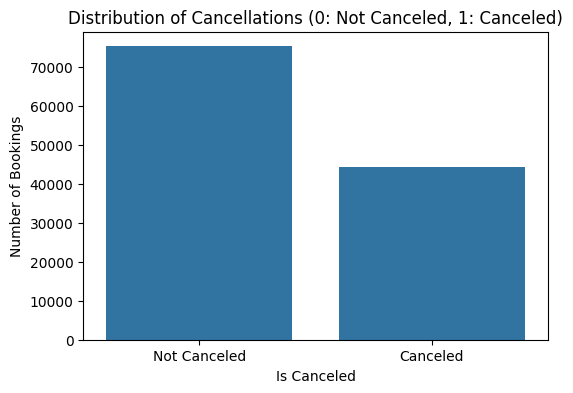

```python
# Create a count plot for the 'is_canceled' variable
plt.figure(figsize=(6, 4))
sns.countplot(data=df, x='is_canceled')
plt.title('Distribution of Cancellations (0: Not Canceled, 1: Canceled)')
plt.xlabel('Is Canceled')
plt.ylabel('Number of Bookings')
plt.xticks([0, 1], ['Not Canceled', 'Canceled']) # Label x-axis ticks
plt.show()
```

```python
#summary analysis for is_canceled
# Use info() for the is_canceled variable
print("Info of is_canceled:")
df['is_canceled'].info()

# Use describe() for the is_canceled variable
print("\nDescription of is_canceled:")
display(df['is_canceled'].describe())

# Use value_counts() for the is_canceled variable
print("\nValue Counts of is_canceled:")
display(df['is_canceled'].value_counts())

# Calculate and display the percentage of cancellations
print("\nPercentage of Cancellations:")
display(df['is_canceled'].value_counts(normalize=True) * 100)
```

```
Info of is_canceled:
<class 'pandas.core.series.Series'>
RangeIndex: 119390 entries, 0 to 119389
Series name: is_canceled
Non-Null Count   Dtype
--------------   -----
119390 non-null  int64
dtypes: int64(1)
memory usage: 932.9 KB

Description of is_canceled:
```

|  | is_canceled |
| --- | --- |
| count | 119390.000000 |
| mean | 0.370416 |
| std | 0.482918 |
| min | 0.000000 |
| 25% | 0.000000 |
| 50% | 0.000000 |
| 75% | 1.000000 |
| max | 1.000000 |

**dtype:** float64

```
Value Counts of is_canceled:
```

| is_canceled | count |
| --- | --- |
| 0 | 75166 |
| 1 | 44224 |

**dtype:** int64

```
Percentage of Cancellations:
```

| is_canceled | proportion |
| --- | --- |
| 0 | 62.958372 |
| 1 | 37.041628 |

**dtype:** float64

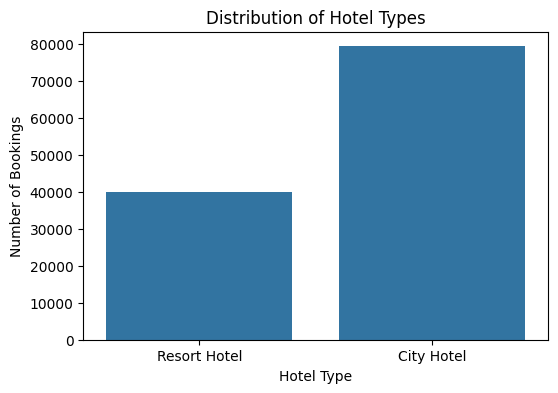

```python
# Create a count plot for the 'hotel' variable
plt.figure(figsize=(6, 4))
sns.countplot(data=df, x='hotel')
plt.title('Distribution of Hotel Types')
plt.xlabel('Hotel Type')
plt.ylabel('Number of Bookings')
plt.show()
```

```python
#summary analysis for hotel type
# Use info() for the hotel variable
print("Info of hotel:")
df['hotel'].info()

# Use describe() for the hotel variable
print("\nDescription of hotel:")
display(df['hotel'].describe())

# Use value_counts() for the hotel variable
print("\nValue Counts of hotel:")
display(df['hotel'].value_counts())

# Calculate and display the percentage of each hotel type
print("\nPercentage of Hotel Types:")
display(df['hotel'].value_counts(normalize=True) * 100)
```

```
Info of hotel:
<class 'pandas.core.series.Series'>
RangeIndex: 119390 entries, 0 to 119389
Series name: hotel
Non-Null Count   Dtype
--------------   -----
119390 non-null  object
dtypes: object(1)
memory usage: 932.9+ KB

Description of hotel:
```

|  | hotel |
| --- | --- |
| count | 119390 |
| unique | 2 |
| top | City Hotel |
| freq | 79330 |

**dtype:** object

```
Value Counts of hotel:
```

| hotel | count |
| --- | --- |
| City Hotel | 79330 |
| Resort Hotel | 40060 |

**dtype:** int64

```
Percentage of Hotel Types:
```

| hotel | proportion |
| --- | --- |
| City Hotel | 66.446101 |
| Resort Hotel | 33.553899 |

**dtype:** float64

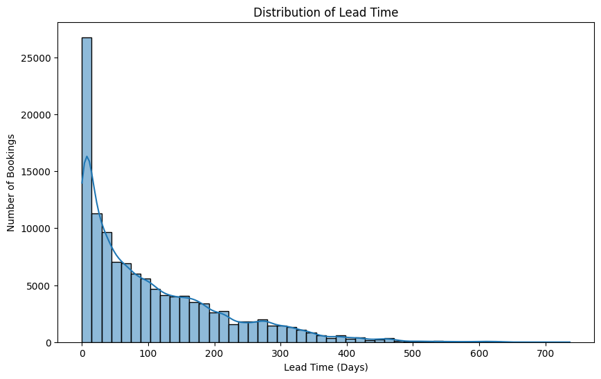

```python
# Create a histogram for the 'lead_time' variable
plt.figure(figsize=(10, 6))
sns.histplot(data=df, x='lead_time', bins=50, kde=True) # Using 50 bins to see the distribution better
plt.title('Distribution of Lead Time')
plt.xlabel('Lead Time (Days)')
plt.ylabel('Number of Bookings')
plt.show()
```

```python
# #summary analysis for lead_time
# Use info() for the lead_time variable
print("Info of lead_time:")
df['lead_time'].info()

# Use describe() for the lead_time variable
print("\nDescription of lead_time:")
display(df['lead_time'].describe())
```

```
Info of lead_time:
<class 'pandas.core.series.Series'>
RangeIndex: 119390 entries, 0 to 119389
Series name: lead_time
Non-Null Count   Dtype
--------------   -----
119390 non-null  int64
dtypes: int64(1)
memory usage: 932.9 KB

Description of lead_time:
```

|  | lead_time |
| --- | --- |
| count | 119390.000000 |
| mean | 104.011416 |
| std | 106.863097 |
| min | 0.000000 |
| 25% | 18.000000 |
| 50% | 69.000000 |
| 75% | 160.000000 |
| max | 737.000000 |

**dtype:** float64

### In your markdown:

1. Variable 1 – What did you explore and what did you find?
2. Variable 2 – What did you explore and what did you find?
3. Variable 3 – What did you explore and what did you find?

### ✍️ Your Response: 🔧

1. The first variable I explored was the is_canceled variable. I found that almost 40% of reservaitions ( 44,224) have been canceled. This shows that there is definetly room to grow for these hotel companies.
2. The second variable I explored was the hotel category. It seems like almost 2/3 of customers stay at the city hotel rather than the resort hotel. This can help us plan different marketing strategies and helps us identify growth spots.
3. The third variable I looked into was the lead time. The lead time distribution is skewed right which indicates that the days between booking and arrival is relitively low, so people usually book pretty close to the time they arrive. This can help give us insights on forcasting demand and planing marketing strategies.

## 5. Bivariate Analysis

Business framing:

Stakeholders often ask: “What drives cancellations?” or “Do longer stays mean higher revenue?” Bivariate analysis helps you uncover those kinds of relationships.

- Choose 2 relevant variable pairs (e.g., `lead_time` vs. `is_canceled`, or `adr` vs. `customer_type`)
- Use scatterplots, grouped bar plots, or boxplots to explore the relationships
- Interpret what these relationships could mean for the hotel business

```python
# Your code to analyze variable relationships (e.g., scatterplots, grouped bars) 🔧
```

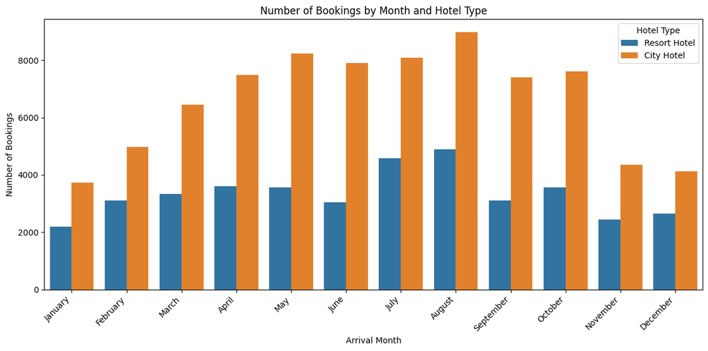

```python
# Create a grouped bar plot comparing arrival_date_month and hotel
plt.figure(figsize=(12, 6))
sns.countplot(data=df, x='arrival_date_month', hue='hotel', order=['January', 'February', 'March', 'April', 'May', 'June', 'July', 'August', 'September', 'October', 'November', 'December']) # Order months chronologically
plt.title('Number of Bookings by Month and Hotel Type')
plt.xlabel('Arrival Month')
plt.ylabel('Number of Bookings')
plt.xticks(rotation=45, ha='right') # Rotate x-axis labels for better readability
plt.legend(title='Hotel Type')
plt.tight_layout() # Adjust layout to prevent labels overlapping
plt.show()
```

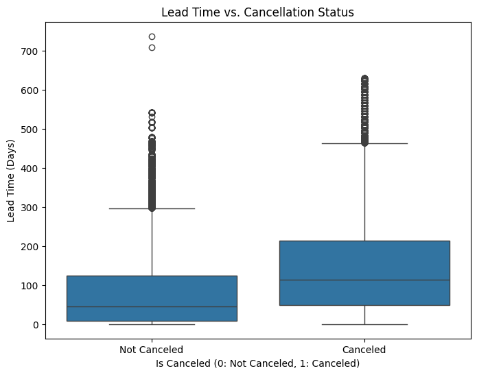

```python
# Create a box plot comparing is_canceled and lead_time
plt.figure(figsize=(8, 6))
sns.boxplot(data=df, x='is_canceled', y='lead_time')
plt.title('Lead Time vs. Cancellation Status')
plt.xlabel('Is Canceled (0: Not Canceled, 1: Canceled)')
plt.ylabel('Lead Time (Days)')
plt.xticks([0, 1], ['Not Canceled', 'Canceled']) # Label x-axis ticks
plt.show()
```

### In your markdown:

1. Relationship 1 – What did you analyze and what insights did you find?
2. Relationship 2 – What did you analyze and what insights did you find?

### ✍️ Your Response: 🔧

1. The first relationship I looked at was the relationship between the time of month and the type of hotel. What I found was that there is an overall increase in stays within the summer months and a decrease in overall stays in the winter months. These insights can help hotels increase their demand in these less visited months.
2. The second relationship I looked into was the number of cancellations vs the lead time. From the data it seems like the more advanced a person books, the more likely they are to cancel.

## 6. Problem Complexity and Analytics Framing

Business framing:

Let’s say you found a strong trend — maybe high lead times predict cancellations, or certain channels bring repeat guests. What kind of problem is this?

- Choose one insight from your earlier analysis
- Reflect on:
  - What type of complexity this problem represents (e.g., variety, volume, variability)
  - What kind of analytics would help solve or explain it (descriptive, diagnostic, predictive, prescriptive)

### In your markdown:

1. What was your selected insight?
2. What kind of complexity does it involve?
3. What type of analytics would help, and why?

### ✍️ Your Response: 🔧

1. My selected insight is comparing the hotel type vs the number of bookings by month.
2. The type of complexity this problem repersents is variability because the number of bookings changes depending on the month.
3. The most helpful analytics would be descriptive. Descriptive analylytics would help us look at the past and present data which would help us understand seasonal trends and decide how to utilize the data to increase bookings.

## 7. Final Takeaways and Recommendations

Business framing:

Imagine you’re preparing for a stakeholder meeting. What would you highlight from your findings?

- Identify your top 2–3 insights or patterns
- Connect each to a stakeholder need or business goal
- Make one recommendation based on the analysis

### In your markdown:

1. What patterns or trends stood out?
2. How do they connect to stakeholder goals?
3. What recommendation would you make based on this analysis?
4. How does this relate to your customized learning outcome you created in canvas?

### ✍️ Your Response: 🔧

1. Some patterns that stood out was the cancelation percentage was relitively high at 40%. Additionally, it seems like there are more cancelations when the hotels are booked in advance. Lastly, the insights about the hotel type showed us that around 2/3 of customers go to the city hotel rather than the resort.
2. These insights connect to the overall stakholder goal of increasing profits and decreasing overall cancellations. The cancelation percentage shows that cancellations are a major issue. The chart that showed that there are more cancelations when booked in advanced identifies a specific factor that influences cancellations. Lastly, for the 2/3 of customers that go to the city hotel vs the resort hotel, this shows the imbalance of damand betweeen the hotel types. This relates to the problem statement directly by needing to increase demand.
3. Based on my analysis, I would recomend that the hotels focust on reducing cancelations and evening out the demand between hotel types. To pinpoint the high cancelations (40%), especially for advanced bookings, they could require a partial non-refundable deposit when booking to make sure that people are commited to their booking. They could also market promotional packages for resort hotels and for when it is the winter( not peak season) to help balance out demand and increase overall profit.
4. This relates to my customized learning outcome of Sustainable Operations Problem- solivng. Being able to reduce cancelations and quantifying the waste due to the unused capaicities can help stakeholders be more motivated to not only reduce unused resorces but also increase overall demand and profit.

## Submission Instructions

✅ **Before submitting:**

- Make sure all code cells are run and outputs are visible
- All markdown questions are answered thoughtfully
- Submit the assignment as an **HTML file** on Canvas

```python
!jupyter nbconvert --to html "assignment_05_NagyCassandra.ipynb"
```